## FEATURIZATION & MODEL TUNING

# PART A - 30 Marks

- **DOMAIN:** Electronics and Telecommunication
- **CONTEXT:** A communications equipment manufacturing company has a product which is responsible for emitting informative signals. Company wants to build a machine learning model which can help the company to predict the equipment’s signal quality using various parameters.
- **DATA DESCRIPTION:** The data set contains information on various signal tests performed:
  1. Parameters: Various measurable signal parameters.
  2. Signal_Quality: Final signal strength or quality
- **PROJECT OBJECTIVE:** To build a classi fier which can use the given parameters to determine the signal strength or quality.

## Steps and tasks: [ Total Score: 30 Marks]

### 1. Data import and Understanding [10 Marks]

1. Read the ‘Signals.csv’ as DataFrame and import required libraries. [2 Marks]
2. Check for missing values and print percentage for each attribute. [2 Marks]
3. Check for presence of duplicate records in the dataset and impute with appropriate method. [2 Marks]
4. Visualise distribution of the target variable. [2 Marks]
5. Share insights from the initial data analysis (at least 2). [2 Marks]

##### Q. 1.A. Read the 'Signals.csv' as DataFrame and import required libraries

```python
#Import required libraries
import pandas as pd
import numpy as np
import matplotlib.pyplot as plt
import seaborn as sns

from sklearn.model_selection import train_test_split
from sklearn.preprocessing import StandardScaler
from tensorflow.keras.utils import to_categorical
from tensorflow.keras.models import Sequential
from tensorflow.keras.layers import Input, Dense, Flatten, BatchNormalization
from tensorflow.keras.layers import LeakyReLU
```

[output not shown]

```python
#Read the 'Signals.csv' file as DataFrame
df = pd.read_csv('Signals.csv')

#Show the first 5 rows of the DataFrame
df.head()
```

|  | Parameter 1 | Parameter 2 | Parameter 3 | Parameter 4 | Parameter 5 | Parameter 6 | Parameter 7 | Parameter 8 | Parameter 9 | Parameter 10 | Parameter 11 | Signal_Strength |
| --- | --- | --- | --- | --- | --- | --- | --- | --- | --- | --- | --- | --- |
| 0 | 7.4 | 0.70 | 0.00 | 1.9 | 0.076 | 11.0 | 34.0 | 0.9978 | 3.51 | 0.56 | 9.4 | 5 |
| 1 | 7.8 | 0.88 | 0.00 | 2.6 | 0.098 | 25.0 | 67.0 | 0.9968 | 3.20 | 0.68 | 9.8 | 5 |
| 2 | 7.8 | 0.76 | 0.04 | 2.3 | 0.092 | 15.0 | 54.0 | 0.9970 | 3.26 | 0.65 | 9.8 | 5 |
| 3 | 11.2 | 0.28 | 0.56 | 1.9 | 0.075 | 17.0 | 60.0 | 0.9980 | 3.16 | 0.58 | 9.8 | 6 |
| 4 | 7.4 | 0.70 | 0.00 | 1.9 | 0.076 | 11.0 | 34.0 | 0.9978 | 3.51 | 0.56 | 9.4 | 5 |

##### Q. 1.B. Check the missing values in the dataset

```python
#Print the data types all the columns
df.dtypes
```

```
Parameter 1        float64
Parameter 2        float64
Parameter 3        float64
Parameter 4        float64
Parameter 5        float64
Parameter 6        float64
Parameter 7        float64
Parameter 8        float64
Parameter 9        float64
Parameter 10       float64
Parameter 11       float64
Signal_Strength      int64
dtype: object
```

- All the 'Parameter' columns (features) are of type float64, so there is no unexpeced data

```python
#Print any null values in the DataFrame
df.isnull().sum()
```

```
Parameter 1        0
Parameter 2        0
Parameter 3        0
Parameter 4        0
Parameter 5        0
Parameter 6        0
Parameter 7        0
Parameter 8        0
Parameter 9        0
Parameter 10       0
Parameter 11       0
Signal_Strength    0
dtype: int64
```

- There are no missing values in the dataset

```python
#Let's check if any values are 0
df.eq(0).sum()
```

```
Parameter 1          0
Parameter 2          0
Parameter 3        132
Parameter 4          0
Parameter 5          0
Parameter 6          0
Parameter 7          0
Parameter 8          0
Parameter 9          0
Parameter 10         0
Parameter 11         0
Signal_Strength      0
dtype: int64
```

- The 'Paramter 3' contains 132 values as 0

```python
#let's check the percentage of 0 values in the column
df.eq(0).sum()/len(df)*100
```

```
Parameter 1        0.000000
Parameter 2        0.000000
Parameter 3        8.255159
Parameter 4        0.000000
Parameter 5        0.000000
Parameter 6        0.000000
Parameter 7        0.000000
Parameter 8        0.000000
Parameter 9        0.000000
Parameter 10       0.000000
Parameter 11       0.000000
Signal_Strength    0.000000
dtype: float64
```

- We are leaving 'zero' values as is, it may be valid values for the parameter.

##### Q. 1.C. Check for presence of duplicate records in the dataset and impute with appropriate method.

```python
#Check for duplicate records
df.duplicated().sum()
```

```
240
```

```python
#Print the percentage of duplicate records
df.duplicated().sum()/len(df)*100
```

```
15.0093808630394
```

- There are 15% duplicate records in the dataset.

```python
#Drop the duplicate records with mean of the column
df = df.drop_duplicates(keep='first').reset_index(drop=True)
```

##### Q. 1.D. Visualise distribution of the target variable (Signal_Strength)

```python
#Print unique values for 'Signal_Strength' column
df['Signal_Strength'].unique()
```

```
array([5, 6, 7, 4, 8, 3], dtype=int64)
```

- There are 6 unique values for the target column 'Signal_Strength' : 3,4,5,6,7 and 8

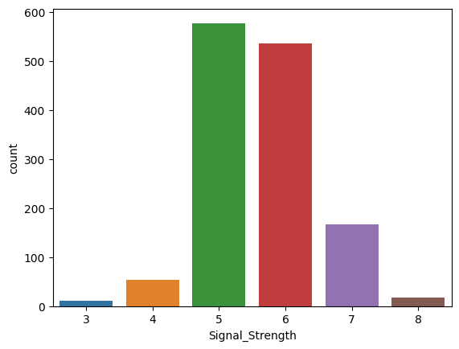

```python
#Visualize the distribution of 'Signal_Strength' column
sns.countplot(x=df['Signal_Strength']);
```

##### 1E. Share insights from the initial data analysis (at least 2).

1. The target variable 'Signal_Strength' is normally distributed.
2. The target variable 'Signal_Strength' has 6 distinct values: 3,4,5,6,7 and 8
3. There are no missing values in the dataset.
4. There are 240 duplicate records in the dataset, which is 15% of the total data, we have dropped these records.
5. All the features are of type float64, so there is no unexpeced data.
6. The target class is highly imbalance, classes 3, 4 and 8 are very less.

### 2. Data preprocessing [7 Marks]

1. Split the data into X & Y. [1 Marks]
2. Split the data into train & test with 70:30 proportion.[1 Marks]
3. Print shape of all the 4 variables and verify if train and test data is in sync. [1 Marks]
4. Normalise the train and test data with appropriate method. [2 Marks]
5. Transform Labels into format acceptable by Neural Network [2 Marks]

#### Q. 2.A. Split the data into X & Y.

```python
#X should contain all the features except the target variable
#Y should contain only the target variable

X = df.drop('Signal_Strength', axis=1)
Y = df['Signal_Strength']
```

#### Q. 2.B. Split the data into train & test with 70:30 proportion.

```python
X_train, X_test, Y_train, Y_test = train_test_split(X, Y,
                                                    test_size=0.30,
                                                    random_state=12,
                                                    stratify = Y)
```

#### Q. 2.C. Print shape of all the 4 variables and verify if train and test data is in sync.

```python
#Print the shape of X_train
print(X_train.shape)
#Print the shape of X_test
print(X_test.shape)
#Print the shape of Y_train
print(Y_train.shape)
#Print the shape of Y_test
print(Y_test.shape)
```

```
(951, 11)
(408, 11)
(951,)
(408,)
```

- So there are 11 featuers and 1 output variable.
- The number features and output variable in train and test data are exactly same.

#### Q. 2.D. Normalise the train and test data with appropriate method.

```python
scaler = StandardScaler()
X_train = scaler.fit_transform(X_train)
X_test = scaler.transform(X_test)
```

#### Q. 2.E. Transform Labels into format acceptable by Neural Network

```python
#We know target variable is categorical, with 6 classes : 3, 4, 5, 6, 7, 8
#If we convert to categorical using to_categorical, it will create 9 output classes : 0, 1, 2, 3, 4, 5,6,7,8
#But we want to create 6 output classes : 3, 4, 5, 6, 7, 8
#So let's subtract 3 from the target variable
Y_train = Y_train - 3
Y_test = Y_test - 3
#Now convert it to categorical variable
#This will create 6 output classes : 0, 1, 2, 3, 4, 5
Y_train = to_categorical(Y_train)
Y_test = to_categorical(Y_test)

#Let's see if the shapes of both train and test data are same
print(Y_train.shape)
print(Y_test.shape)
```

```
(951, 6)
(408, 6)
```

### 3. Model Training & Evaluation using Neural Network [13 Marks]

1. Design a Neural Network to train a classifier. [3 Marks]
2. Train the classifier using previously designed Architecture [2 Marks]
3. Plot 2 separate visuals. [3 Marks]
   1. Training Loss and Validation Loss
   2. Training Accuracy and Validation Accuracy
4. Design new architecture/update existing architecture in attempt to improve the performance of the model. [2 Marks]
5. Plot visuals as in Q3.C and share insights about difference observed in both the models. [3 Marks]

#### Q. 3.A. Design a Neural Network to train a classifier.

```python
#We have 11 input features and 6 output classes
features = 11
classes = 6

#Let's define Loss function, Optimizer and Metrics : accuracy

loss_function = 'categorical_crossentropy'
optimizer = 'sgd'
metrics = ['accuracy']

#Initialize the model
model = Sequential()

#Input layer
model.add(Input(features))

#One hidden layer with 32 neurons
model.add(Dense(32, activation='relu'))

#output layer : we need convert the output to 9 classes using 'softmax' activation function
model.add(Dense(classes, activation='softmax'))

#Compile the model and print the summary
model.compile(loss=loss_function, optimizer=optimizer, metrics=metrics)
model.summary()
```

```
WARNING:tensorflow:From C:\Users\tuhin.sengupta\AppData\Local\Packages\PythonSoftwareFoundation.Python.3.11_qbz5n2kfra8p0\LocalCache\local-packages\Python311\site-packages\keras\src\backend.py:873: The name tf.get_default_graph is deprecated. Please use tf.compat.v1.get_default_graph instead.

WARNING:tensorflow:From C:\Users\tuhin.sengupta\AppData\Local\Packages\PythonSoftwareFoundation.Python.3.11_qbz5n2kfra8p0\LocalCache\local-packages\Python311\site-packages\keras\src\optimizers\__init__.py:309: The name tf.train.Optimizer is deprecated. Please use tf.compat.v1.train.Optimizer instead…

Model: "sequential"
_________________________________________________________________
 Layer (type)                Output Shape              Param #
=================================================================
 dense (Dense)               (None, 32)                384

 dense_1 (Dense)             (None, 6)                 198

=================================================================
Total params: 582 (2.27 KB)
Trainable params: 582 (2.27 KB)
Non-trainable params: 0 (0.00 Byte)
_________________________________________________________________
```

#### Q. 3.B. Train the classifier using previously designed Architecture

```python
#Train the model for 500 epochs with batch size of 100
EPOCH=500
Network_Regressor=model.fit(X_train, Y_train, validation_data=(X_test,Y_test), epochs=EPOCH, batch_size=100)
```

[output not shown]

#### Q. 3C. Plot graphs of:

- Training Loss and Validation Loss
- Training Accuracy and Validation Accuracy

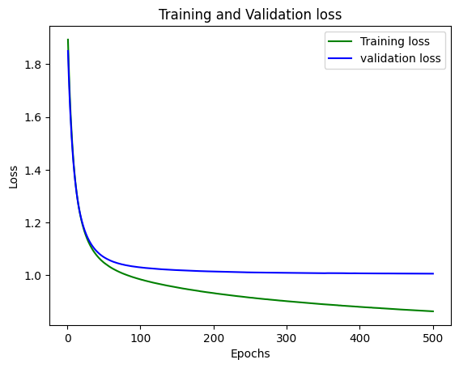

```python
#Plot the graph of Training and Validation loss
loss_train = Network_Regressor.history['loss']
loss_val = Network_Regressor.history['val_loss']
epochs = range(1,EPOCH+1)
plt.plot(epochs, loss_train, 'g', label='Training loss')
plt.plot(epochs, loss_val, 'b', label='validation loss')
plt.title('Training and Validation loss')
plt.xlabel('Epochs')
plt.ylabel('Loss')
plt.legend()
plt.show()
```

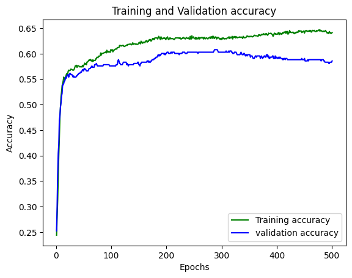

```python
#Plot graph of Training Accuracy and Validation Accuracy
acc_train = Network_Regressor.history['accuracy']
acc_val = Network_Regressor.history['val_accuracy']
epochs = range(1,EPOCH+1)
plt.plot(epochs, acc_train, 'g', label='Training accuracy')
plt.plot(epochs, acc_val, 'b', label='validation accuracy')
plt.title('Training and Validation accuracy')
plt.xlabel('Epochs')
plt.ylabel('Accuracy')
plt.legend()
plt.show()
```

```python
#Let's print the classification report
from sklearn.metrics import classification_report

Y_pred = model.predict(X_test)
Y_pred_value = np.argmax(Y_pred, axis=1)
Y_test_value = np.argmax(Y_test, axis=1)

print(classification_report(Y_test_value, Y_pred_value))
```

```
              precision    recall  f1-score   support

           0       0.00      0.00      0.00         3
           1       0.00      0.00      0.00        16
           2       0.64      0.74      0.69       173
           3       0.55      0.60      0.57       161
           4       0.45      0.30      0.36        50
           5       0.00      0.00      0.00         5

    accuracy                           0.59       408
   macro avg       0.27      0.27      0.27       408
weighted avg       0.55      0.59      0.56       408
```

[output not shown]

- The warning above is due to fact that model never predicted classes 0, 1 and 5 (in origical data set, classes 3,4 and 8) - because their presence is very less in original dataset.

#### Q. 3.D. Design new architecture/update existing architecture in attempt to improve the performance of the model.

```
(3462, 11)
(3462,)
```

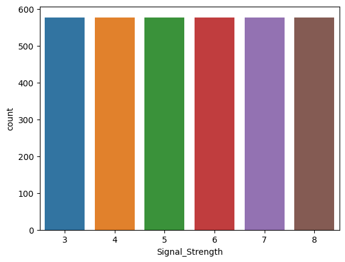

```python
#Let's fix the imbalance of output classes by creating new dataset using SMOTE
from imblearn.over_sampling import SMOTE
#Create object of SMOTE class
smote = SMOTE(random_state=42)

#Create data X_smote and Y_smote using SMOTE
X_smote, Y_smote = smote.fit_resample(X, Y)

#Let's check the shape of X_smote and Y_smote
print(X_smote.shape)
print(Y_smote.shape)

#Let's plot the distribution of target variable
sns.countplot(x=Y_smote);
```

```python
#Now split the data into train and test
X_train, X_test, Y_train, Y_test = train_test_split(X_smote, Y_smote,
                                                    test_size=0.30,
                                                    random_state=12,
                                                    stratify = Y_smote)
```

```python
#Scale the data
scaler = StandardScaler()
X_train = scaler.fit_transform(X_train)
X_test = scaler.transform(X_test)
```

```python
#Change to categorial classes
#We know target variable is categorical, with 6 classes : 3, 4, 5, 6, 7, 8
#If we convert to categorical using to_categorical, it will create 9 output classes : 0, 1, 2, 3, 4, 5,6,7,8
#But we want to create 6 output classes : 3, 4, 5, 6, 7, 8
#So let's subtract 3 from the target variable
Y_train = Y_train - 3
Y_test = Y_test - 3
#Now convert it to categorical variable
#This will create 6 output classes : 0, 1, 2, 3, 4, 5
Y_train = to_categorical(Y_train)
Y_test = to_categorical(Y_test)

#Let's see if the shapes of both train and test data are same
print(Y_train.shape)
print(Y_test.shape)
```

```
(2423, 6)
(1039, 6)
```

```python
#Now create the model
from tensorflow.keras.layers import Dropout
#Out second design as below:

#Let's define Loss function, Optimizer and Metrics : accuracy

loss_function = 'categorical_crossentropy'
optimizer = 'adam'
metrics = ['accuracy']

model2 = Sequential()

# The Input Layer with Batch Normalization
model2.add(BatchNormalization(input_dim=features) )

# Three Hidden Layers : with 64, 32 and 16 neurons each.
model2.add(Dense(64,activation='relu'))
model2.add(BatchNormalization())
model2.add(Dropout(0.4))
model2.add(Dense(32, activation='relu'))
model2.add(BatchNormalization())
model2.add(Dropout(0.4))
model2.add(Dense(16, activation='relu'))
model2.add(BatchNormalization())
model2.add(Dropout(0.4))

# The Output Layer : with 9 classes output
model2.add(Dense(classes, activation='softmax'))

# Compile the network :
model2.compile(loss=loss_function, optimizer=optimizer, metrics=metrics)

model2.summary()

#Train the model for 500 epochs with batch size of 100
EPOCH=500
Network_Regressor=model2.fit(X_train, Y_train, validation_data=(X_test,Y_test), epochs=EPOCH, batch_size=200)
```

```
Model: "sequential_1"

_________________________________________________________________
 Layer (type)                Output Shape              Param #
=================================================================
 batch_normalization (Batch  (None, 11)                44
 Normalization)

 dense_2 (Dense)             (None, 64)                768

 batch_normalization_1 (Bat  (None, 64)                256
 chNormalization)

 dropout (Dropout)           (None, 64)                0

 dense_3 (Dense)             (None, 32)                2080

 batch_normalization_2 (Bat  (None, 32)                128
 chNormalization)

 dropout_1 (Dropout)         (None, 32)                0

 dense_4 (Dense)             (None, 16)                528

 batch_normalization_3 (Bat  (None, 16)                64
 chNormalization)

 dropout_2 (Dropout)         (None, 16)                0

 dense_5 (Dense)             (None, 6)                 102

=================================================================
Total params: 3970 (15.51 KB)
Trainable params: 3724 (14.55 KB)
Non-trainable params: 246 (984.00 Byte)
_________________________________________________________________
```

#### Q. 3.E. Plot visuals as in Q3.C and share insights about difference observed in both the models.

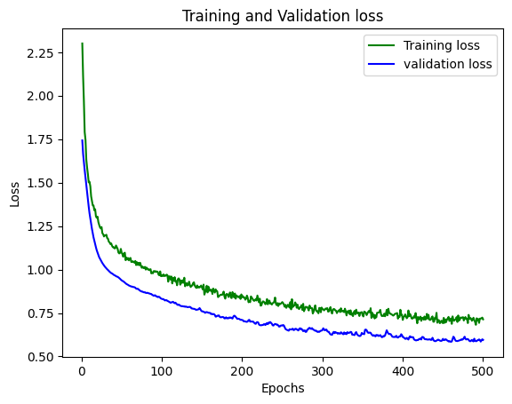

```python
#Training Loss and Validation Loss
loss_train = Network_Regressor.history['loss']
loss_val = Network_Regressor.history['val_loss']
epochs = range(1,EPOCH+1)
plt.plot(epochs, loss_train, 'g', label='Training loss')
plt.plot(epochs, loss_val, 'b', label='validation loss')
plt.title('Training and Validation loss')
plt.xlabel('Epochs')
plt.ylabel('Loss')
plt.legend()
plt.show()
```

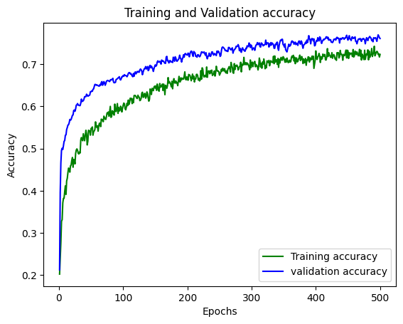

```python
#Training Accuracy and Validation Accuracy
accu_train = Network_Regressor.history['accuracy']
accu_val = Network_Regressor.history['val_accuracy']
epochs = range(1,EPOCH+1)
plt.plot(epochs, accu_train, 'g', label='Training accuracy')
plt.plot(epochs, accu_val, 'b', label='validation accuracy')
plt.title('Training and Validation accuracy')
plt.xlabel('Epochs')
plt.ylabel('Accuracy')
plt.legend()
plt.show()
```

```python
#Let's print classification metrics
#Let's print the classification report
from sklearn.metrics import classification_report

Y_pred = model2.predict(X_test)
Y_pred_value = np.argmax(Y_pred, axis=1)
Y_test_value = np.argmax(Y_test, axis=1)

print(classification_report(Y_test_value, Y_pred_value))
```

```
              precision    recall  f1-score   support

           0       0.95      1.00      0.97       173
           1       0.77      0.95      0.85       173
           2       0.63      0.48      0.54       173
           3       0.52      0.35      0.42       174
           4       0.69      0.79      0.74       173
           5       0.88      0.99      0.93       173

    accuracy                           0.76      1039
   macro avg       0.74      0.76      0.74      1039
weighted avg       0.74      0.76      0.74      1039
```

- Now there is no warning as all classes are predicted.

#### Insights about both models:

- The first model has 1 hidden layer with 32 neurons and the second model has 3 hidden layers with 64,32 and 16 neurons each.
- The first model has SGD optimizer and the second model has Adam optimizer.
- Batch size for first model was 100 wheras second model batch size was set to 200.
- The data oversampling also used in second model to handle the target class imbalncing.
- The second model has Batch normalization as well as Dropout to reduce overfitting.
- First model gave overall accuracy of 58% whereas has given 75% accuracy on test data.

# PART B - 30 Marks

- **DOMAIN:** Autonomous Vehicles
- **CONTEXT:** A Recognising multi-digit numbers in photographs captured at street level is an important component of modern-day map making. A classic example of a corpus of such street-level photographs is Google’s Street View imagery composed of hundreds of millions of geo-located 360-degree panoramic images.  
  The ability to automatically transcribe an address number from a geo-located patch of pixels and associate the transcribed number with a known street address helps pinpoint, with a high degree of accuracy, the location of the building it represents. More broadly, recognising numbers in photographs is a problem of interest to the optical character recognition community.  
  While OCR on constrained domains like document processing is well studied, arbitrary multi-character text recognition in photographs is still highly challenging. This difficulty arises due to the wide variability in the visual appearance of text in the wild on account of a large range of fonts, colours, styles, orientations, and character arrangements.  
  The recognition problem is further complicated by environmental factors such as lighting, shadows, specularity, and occlusions as well as by image acquisition factors such as resolution, motion, and focus blurs. In this project, we will use the dataset with images centred around a single digit (many of the images do contain some distractors at the sides). Although we are taking a sample of the data which is simpler, it is more complex than MNIST because of the distractors.
- **DATA DESCRIPTION:** The SVHN is a real-world image dataset for developing machine learning and object recognition algorithms with the minimal requirement on data formatting but comes from a significantly harder, unsolved, real-world problem (recognising digits and numbers in natural scene images). SVHN is obtained from house numbers in Google Street View images.  
  Where the labels for each of this image are the prominent number in that image i.e. 2,6,7 and 4 respectively. The dataset has been provided in the form of h5py files. You can read about this file format here: https://docs.h5py.org/en/stable/ Acknowledgement: Yuval Netzer, Tao Wang, Adam Coates, Alessandro Bissacco, Bo Wu, Andrew Y. Ng Reading Digits in Natural Images with Unsupervised Feature Learning NIPS Workshop on Deep Learning and Unsupervised Feature Learning 2011. PDF http://ufldl.stanford.edu/housenumbers as the URL for this site.
- **PROJECT OBJECTIVE:** To build a digit classi fier on the SVHN (Street View Housing Number) dataset.

## Steps and tasks: [ Total Score: 30 Marks]

### 1. Data Import and Exploration [5 Marks]

1. Read the .h5 file and assign to a variable. [2 Marks]
2. Print all the keys from the .h5 file. [1 Marks]
3. Split the data into X_train, X_test, Y_train, Y_test [2 Marks]

#### Q. 1.A. Read the .h5 file and assign to a variable.

```python
#Read the Autonomous_Vehicles_SVHN_single_grey1.h5 file

import h5py
auto_df = h5py.File('Autonomous_Vehicles_SVHN_single_grey1.h5', 'r')
```

#### Q. 1.B. Print all the keys from the .h5 file.

```python
#Print all keys from auto_df
for key in auto_df.keys():
    print(key)
```

```
X_test
X_train
X_val
y_test
y_train
y_val
```

#### Q. 1.C. Split the data into X_train, X_test, Y_train, Y_Test.

```python
## This question (and all below questions) is asking for only train and test datasets.
## But the file has train, test and validation datasets.
## So I am using train, validation and test datasets from the file for all below questions.

#Split the data into X_train, X_val, X_test, y_train, y_val, y_test
X_train = auto_df['X_train'][:]
X_val = auto_df['X_val'][:]
X_test = auto_df['X_test'][:]
y_train = auto_df['y_train'][:]
y_val = auto_df['y_val'][:]
y_test = auto_df['y_test'][:]
```

```python
#Close the file
auto_df.close()
```

### 2. Data Visualisation and preprocessing [13 Marks]

1. Print shape of all the 4 data split into x, y, train, test to verify if x & y is in sync. [1 Marks]
2. Visualise first 10 images in train data and print its corresponding labels. [4 Marks]
3. Reshape all the images with appropriate shape update the data in same variable. [3 Marks]
4. Normalise the images i.e. Normalise the pixel values. [2 Marks]
5. Transform Labels into format acceptable by Neural Network [2 Marks]
6. Print total Number of classes in the Dataset. [1 Marks]

#### Q. 2.A. Print shape of all the 4 data split into x, y, train, test to verify if x & y is in sync.

```python
## Again I am using validation set as well

#Print shape of all 6 data split into x,y,train, validation and test to verify if x & y are in sync
print(X_train.shape)
print(X_val.shape)
print(X_test.shape)
print(y_train.shape)
print(y_val.shape)
print(y_test.shape)
```

```
(42000, 32, 32)
(60000, 32, 32)
(18000, 32, 32)
(42000,)
(60000,)
(18000,)
```

- So nunmber of features and output are exactly same in train, validation and test dataset

#### Q. 2.B. Visualise first 10 images in train data and print its corresponding labels.

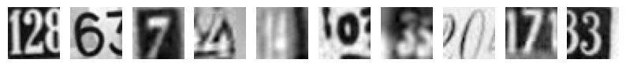

```
label for each of the above image: [2 6 7 4 4 0 3 0 7 3]
```

```python
#Visualize the first 10 images in X_train and print their corresponding labels
plt.figure(figsize=(10,10))
for i in range(10):
    plt.subplot(1,10,i+1)
    plt.imshow(X_train[i], cmap='gray')
    plt.axis('off')
plt.show()
print('label for each of the above image: %s' % (y_train[0:10]))
```

#### Q. 2.C. Reshape all the images with appropriate shape update the data in same variable.

```python
#Reshape all the images to flatten them into a single dimension array
#The image size is 32x32

image_vector_size = 32*32


X_train = X_train.reshape(X_train.shape[0], image_vector_size)
X_val = X_val.reshape(X_val.shape[0], image_vector_size)
X_test = X_test.reshape(X_test.shape[0], image_vector_size)
```

#### Q. 2.D. Normalise the images i.e. Normalise the pixel values.

```python
#Normalize the images

X_train = X_train.astype('float32')
X_val = X_val.astype('float32')
X_test = X_test.astype('float32')

X_train /= 255
X_val /= 255
X_test /= 255

print("X_train shape:", X_train.shape)
print("X_val shape:", X_val.shape)
print("X_test shape:", X_test.shape)

print("Images in X_train:", X_train.shape[0])
print("Images in X_val:", X_val.shape[0])
print("Images in X_test:", X_test.shape[0])
```

```
X_train shape: (42000, 1024)
X_val shape: (60000, 1024)
X_test shape: (18000, 1024)
Images in X_train: 42000
Images in X_val: 60000
Images in X_test: 18000
```

#### Q. 2.E. Transform Labels into format acceptable by Neural Network

```python
#Print the unique numbers in y_train, y_val and y_test
print(np.unique(y_train))
print(np.unique(y_val))
print(np.unique(y_test))
```

```
[0 1 2 3 4 5 6 7 8 9]
[0 1 2 3 4 5 6 7 8 9]
[0 1 2 3 4 5 6 7 8 9]
```

```python
#So we have 10 classes in both train and test data
#Convert y_train, y_val and y_test to categorical binary values
y_train = to_categorical(y_train, 10)
y_val = to_categorical(y_val, 10)
y_test = to_categorical(y_test, 10)
```

#### Q. 2.F. Print total Number of classes in the Dataset.

```python
#Print total number of classes in y_train, y_val and y_test


print("Number of classes in y_train:", y_train.shape[1])
print("Number of classes in y_val:", y_val.shape[1])
print("Number of classes in y_test:", y_test.shape[1])

#Print the unique values of the classes in y_train, y_val and y_test
print("Number of unique values in y_train:", np.unique(y_train))
print("Number of unique values in y_val:",np.unique(y_val))
print("Number of unique values in y_test:",np.unique(y_test))
```

```
Number of classes in y_train: 10
Number of classes in y_val: 10
Number of classes in y_test: 10
Number of unique values in y_train: [0. 1.]
Number of unique values in y_val: [0. 1.]
Number of unique values in y_test: [0. 1.]
```

- There are 10 classes in each dataset

### 3. Model Training & Evaluation using Neural Network [12 Marks]

1. Design a Neural Network to train a classifier. [3 Marks]
2. Train the classifier using previously designed Architecture (Use best suitable parameters). [3 Marks]
3. Evaluate performance of the model with appropriate metrics. [2 Marks]
4. Plot the training loss, validation loss vs number of epochs and training accuracy, validation accuracy vs number of epochs plot and write your observations on the same. [4 Marks]

#### Q. 3.A. Design a Neural Network to train a classifier.

```python
#Design a Neural Network model with below architecture:
import tensorflow as tf

#Clear out tensorflow memory
tf.keras.backend.clear_session()

# For early stopping of model.
callbacks=tf.keras.callbacks.EarlyStopping(monitor='loss', patience=5)

#Initialize Sequential model
model = tf.keras.models.Sequential()


#Normalize the data
model.add(tf.keras.layers.BatchNormalization(input_shape=(image_vector_size,)))

#Add 1st hidden layer
model.add(tf.keras.layers.Dense(128, activation='relu'))
#Add a dropout layer
model.add(tf.keras.layers.Dropout(0.2))

#Add 2nd hidden layer
model.add(tf.keras.layers.Dense(64, activation='relu'))
#Add a dropout layer
model.add(tf.keras.layers.Dropout(0.2))

#Add 3rd hidden layer
model.add(tf.keras.layers.Dense(32, activation='relu'))
#Add a dropout layer
model.add(tf.keras.layers.Dropout(0.2))


#Add OUTPUT layer
model.add(tf.keras.layers.Dense(10, activation='softmax'))

model.compile(optimizer='adam', loss='categorical_crossentropy', metrics=['accuracy'])
model.summary()
```

```
Model: "sequential"
_________________________________________________________________
 Layer (type)                Output Shape              Param #
=================================================================
 batch_normalization (Batch  (None, 1024)              4096
 Normalization)

 dense (Dense)               (None, 128)               131200

 dropout (Dropout)           (None, 128)               0

 dense_1 (Dense)             (None, 64)                8256

 dropout_1 (Dropout)         (None, 64)                0

 dense_2 (Dense)             (None, 32)                2080

 dropout_2 (Dropout)         (None, 32)                0

 dense_3 (Dense)             (None, 10)                330

=================================================================
Total params: 145962 (570.16 KB)
Trainable params: 143914 (562.16 KB)
Non-trainable params: 2048 (8.00 KB)
_________________________________________________________________
```

#### Q. 3.B. Train the classifier using previously designed Architecture (Use best suitable parameters).

```python
#Train the model
#We are using 200 epochs, as we have used early stopping callback
#We will use validation set for validation
history=model.fit(X_train, y_train, epochs=200, batch_size=200, verbose=1, validation_data=(X_val, y_val),  callbacks=[callbacks])
```

#### Q. 3.C. Evaluate performance of the model with appropriate metrics.

```python
#Evaluate the model
score = model.evaluate(X_test, y_test, verbose=0)
print('Test loss:', score[0])
print('Test accuracy:', score[1])
```

```
Test loss: 0.47102999687194824
Test accuracy: 0.8593888878822327
```

```python
#Print the classification report
from sklearn.metrics import classification_report
y_pred=model.predict(X_test)
y_pred_value = np.argmax(y_pred, axis=1)
y_test_value = np.argmax(y_test, axis=1)
#Show the classification report
print(classification_report(y_test_value, y_pred_value))
```

```
              precision    recall  f1-score   support

           0       0.86      0.91      0.88      1814
           1       0.83      0.89      0.86      1828
           2       0.91      0.85      0.88      1803
           3       0.83      0.83      0.83      1719
           4       0.89      0.88      0.89      1812
           5       0.87      0.84      0.86      1768
           6       0.86      0.84      0.85      1832
           7       0.86      0.90      0.88      1808
           8       0.81      0.82      0.82      1812
           9       0.88      0.82      0.85      1804

    accuracy                           0.86     18000
   macro avg       0.86      0.86      0.86     18000
weighted avg       0.86      0.86      0.86     18000
```

#### Q. 3.D. Plot the training loss, validation loss vs number of epochs and training accuracy, validation accuracy vs number of epochs plot and write your observations on the same.

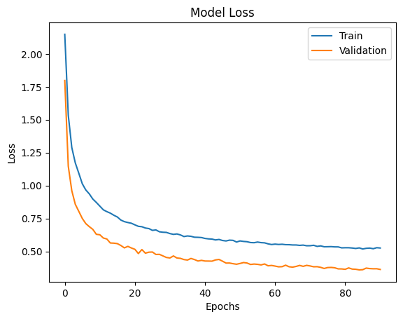

```python
#Plot the graph for training and validation loss vs number of epochs
plt.plot(history.history['loss'])
plt.plot(history.history['val_loss'])
plt.title('Model Loss')
plt.ylabel('Loss')
plt.xlabel('Epochs')
plt.legend(['Train', 'Validation'], loc='upper right')
plt.show()
```

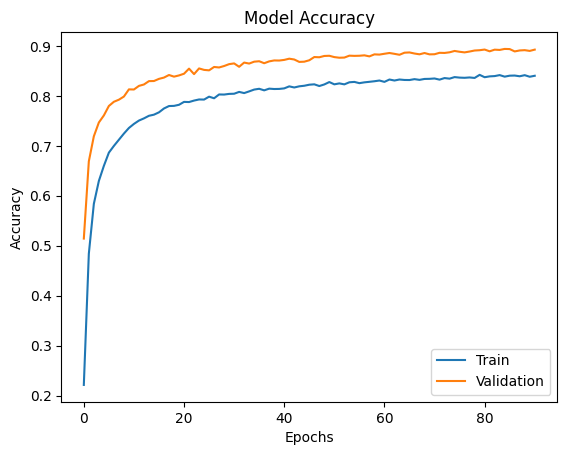

```python
#Plot the graph for training and validation accuracy vs number of epochs
plt.plot(history.history['accuracy'])
plt.plot(history.history['val_accuracy'])
plt.title('Model Accuracy')
plt.ylabel('Accuracy')
plt.xlabel('Epochs')
plt.legend(['Train', 'Validation'], loc='lower right')
plt.show()
```

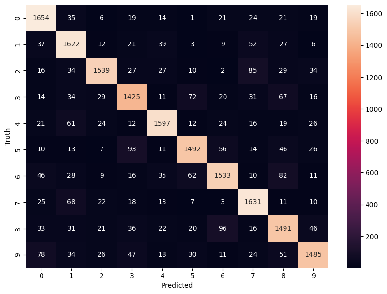

```python
#Print confusion matrix
from sklearn.metrics import confusion_matrix

cm=confusion_matrix(y_test_value,y_pred_value)

plt.figure(figsize=(10,7))
sns.heatmap(cm,annot=True,fmt='d')
plt.xlabel('Predicted')
plt.ylabel('Truth')
plt.show()
```

```python
#Show misclassified images
index = 0
misclassified_images = []
for label, predict in zip(y_test_value, y_pred_value):
    if label != predict:
        misclassified_images.append(index)
    index +=1
print(misclassified_images)
print(len(misclassified_images))
```

```
[8, 11, 27, 40, 45, 56, 58, 64, 68, 85, 93, 100, 102, 108, 127, 132, 137, 138, 149, 150, 155, 182, 183, 184, 185, 199, 200, 203, 222, 223, 230, 232, 239, 252, 253, 256, 267, 284, 300, 303, 307, 317, 324, 337, 347, 348, 360, 363, 372, 374, 403, 404, 432, 437, 448, 451, 456, 457, 466, 480, 489, 498, 5…
2531
```

```
=======================================
Image Index: 8
=======================================
```

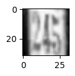

```
Was predicted  1
Was labeled  4
Predicted Probabilities:  [[0.00573256 0.9350296  0.00328891 0.00236538 0.03388159 0.00156277
  0.00501789 0.00286233 0.00462264 0.00563643]]




=======================================
Image Index: 11
=======================================
```

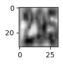

```
Was predicted  2
Was labeled  9
Predicted Probabilities:  [[0.06653041 0.06649569 0.4014077  0.1141112  0.06105415 0.03514225
  0.01579981 0.0468854  0.06224535 0.13032806]]




=======================================
Image Index: 27
=======================================
```

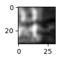

```
Was predicted  7
Was labeled  1
Predicted Probabilities:  [[0.18325423 0.18373197 0.15703952 0.04159239 0.02502173 0.01287065
  0.02936078 0.24242637 0.0595542  0.06514812]]




=======================================
Image Index: 40
=======================================
```

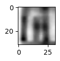

```
Was predicted  0
Was labeled  6
Predicted Probabilities:  [[0.43353516 0.05624296 0.00699873 0.01746334 0.04386731 0.02442878
  0.22595142 0.01095245 0.14875351 0.03180639]]




=======================================
Image Index: 45
=======================================
```

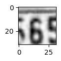

```
Was predicted  5
Was labeled  6
Predicted Probabilities:  [[7.4837916e-04 3.2274931e-04 1.3313340e-03 2.8597906e-02 5.0918814e-03
  6.8296880e-01 1.8910468e-01 3.8650804e-04 7.1266659e-02 2.0181084e-02]]
```

```python
#Let's see some misclassifeid images
for image_index in misclassified_images[0:5]:
    print("\n\n\n\n=======================================")
    print(f"Image Index: {image_index}")
    print("=======================================")
    plt.figure(figsize=(1,1))
    plt.imshow(X_test[image_index].reshape(32, 32),cmap='Greys')
    plt.show()
    pred = model.predict(X_test[image_index].reshape(-1, 1024))
    print("Was predicted ",pred.argmax())
    print("Was labeled ",y_test_value[image_index])
    print("Predicted Probabilities: ",pred)
```